# Klk_Genes_Data_Analysis

Anouk Dupe, Maria Yemane, Dustin Schilling, David Eckey

06.07.2021

# 1. Introduction

KLKs are a family of 15 mammalian secreted serine proteases. Analysis has shown that the KLK locus is most likely located on chromosome 19 and forms the largest cluster of contiguous proteases in the entire genome. (Yousef et al. 2000).  
All 15 kallikrein genes are proteolytic enzymes of steroid hormone regulation and are involved in the regulation of blood pressure, tissue remodeling, skin desquamation, and many other processes. The structure of KLK are similar with two beta-drums, two alpha-helices and a distinct loop involved in the regulation of activity and selectivity. Currently, the specific role of each kallikrein is unclear. It is known that they are involved in the complex regulatory processes, more specifically in those different signaling cascades.  
Dysregulation of KLKs are frequently associated with cancer. Their expression in different tissues and their involvement in different physiological processes make them potential tumor expression markers (Fischer and Meyer-Hoffert, 2013).  
Differential expression of different kallikrein genes has been found in different cancer types. While clear cell and papillary renal carcinomas have similar kallikrein expression profiles, chromophobe renal cell carcinoma has a unique expression profile (Tailor et al. 2018).

# 2. Quality control

After reading in our data, the first step is to verify its quality by following the steps presented in “R Course Micoarray Analysis” by Dr. Maria Dinkelacker (2019). The goal of quality control is to identify samples for which the data characteristics are significantly different. This significantly different expression would then be difficult to remove via variance stabilizing normalisation (vsn) and could interfere with the rest of the data. Samples that show odd characteristic will thereby be identified and replaced in the following quality control. The quality control is performed of the breast cancer microarray data set GSE65216 (Maire et al. 2013) and the small cell lung cancer microarray data set GSE149507 (Cai et al. 2021).

## 2.1 Quality control - GSE65216 breast cancer

### Single chip control

An example image of the scanned arrays is displayed. Upon examination of each array, there are no scratches or lighter areas detectable, which means the arrays themselves are fine.

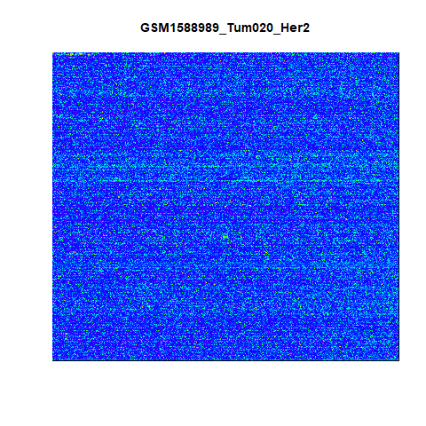

Working chip of breast cancer microarray GSE65216

### meanSd plot

The meanSd plot shows the standard deviation of the vsn normalized data, across all samples, plotted against the mean. Here, the logarithmic transformation consists with the base of 2.

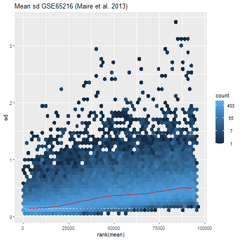

meanSD plot of breast cancer microarray GSE65216

### Boxplots before and after normalisation

It is clearly visible, that the differences in intensities between arrays is strongly reduced after normalisation. Also the boxplots only show little fluctuation in gene expression for the 20 arrays after normalisation. This means all chips adjudted through vsnrma normalisation

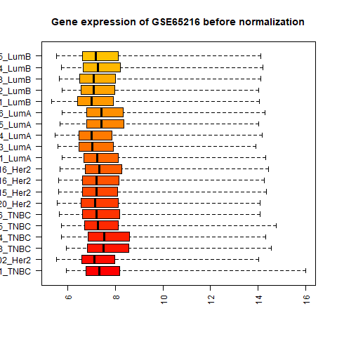

Boxplots before and after normalisation breast cancer GSE65216

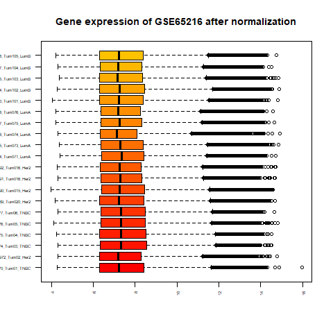

Boxplots before and after normalisation breast cancer GSE65216

### Density function

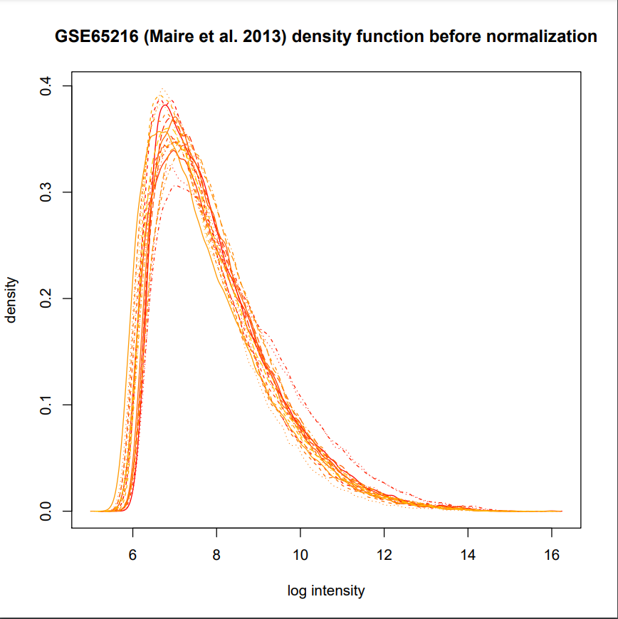

Density functions before and after normalisation breast cancer GSE65216

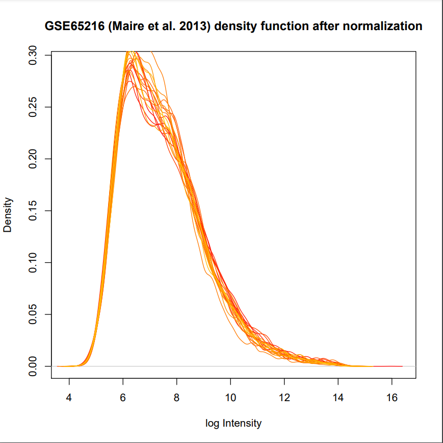

Density functions before and after normalisation breast cancer GSE65216

### RNA degeneration plot

[figure not shown]

Example of scatter plot breast cancer GSE65216

## 2.2 Quality control - GSE149507 lung cancer

### Scatter plots

The carcinoma tissue sample of patient number 5 did not show linear relationship to all of the other samples. Since the samples of dataset GSE149507 for normal and carcinoma tissue are linked to one patient each, we consequently replaced the two chips GSM4504109_SCLC_05_ca and GSM4504110_SCLC_05_ with new 2 new chips out of the gene expression omnibus. When performing the scatter plot control over again, there are no discrepancies anymore.

[figure not shown]

# 3. Further data acquistion

## Importing and unification of TRA data

To distinguish between TRA KLK genes and non-TRA KLK genes, we imported a total of 6 TRA data sets ((Su et al. 2002, 2004), (Roth et al. 2008), (Lattin et al. 2006), (human GTEX data 2015), (Uhlén et al. 2015)). Also below you can see an overview of the tissues that display TRAs in the context of the whole data set.

To get an overview about the distribution of Tissue Restricted Antigens, especially those that are Kallikrein genes, a pie chart was conducted. A pie chart in general allows a quick overview and a first assessment of numerical distribution values. In this pie chart, the distribution of Tissue Restricted Kallikrein-Antigens is displayed. Notable is the high prevalence of prostatic kallikrein genes, as well as an occurrence in esophagus, thyroid and salivary gland. Starting by combining the six given TRA data sets, a fusion data frame was created. From this data frame, all genes that are KLKs are extracted. Since six data sets were combined, annotations for the same tissue were different, which needed to be fused manually. For the tissue “skin” as an example there were 3 tissues given: “skin”, “Skin – Sun exposed” and “Skin – not Sun exposed”. All those were combined into “skin”.

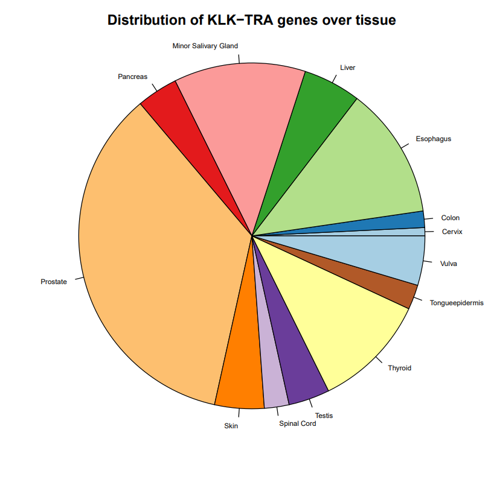

Tissue specificy of KLK genes

# 4. Expression Analysis

## Extraction of KLK and KLK TRA genes

With the unified TRA data set Union.TRA, it is possible to extract all KLKs that are tissue-restricted by their transcript number.

## 4.2 Breast cancer GSE65216 (Maire et al. 2013)

### Visualization of gene expression

#### Overview gene expression

Since the data is vsnrma normalized, the median does not fluctuate too much for all samples. The lowest gene expression value is about 5 while the highest gene expression value is around 15. Due to the logarithmic scale with a base of 2, a log-fold change of +1 represents a two times as high gene expression.

```r
gene.summary <- function(x){
 round(apply(x, 2, summary), digits = 2)
}
gene.summary(breastExprs)
```

```
##         GSM1588970_Tum01_TNBC GSM1588972_Tum02_Her2 GSM1588974_Tum03_TNBC
## Min.                     4.92                  4.88                  5.27
## 1st Qu.                  6.52                  6.56                  6.53
## Median                   7.39                  7.39                  7.32
## Mean                     7.67                  7.66                  7.62
## 3rd Qu.                  8.53                  8.45                  8.38
## Max.                    16.02                 14.94                 14.23
##         GSM1588975_Tum04_TNBC GSM1588976_Tum05_TNBC GSM1588977_Tum06_TNBC
## Min.                     5.29                  4.85                  5.09
## 1st Qu.                  6.52                  6.59                  6.56
## Median                   7.31                  7.45                  7.41
## Mean                     7.61                  7.73                  7.68
## 3rd Qu.                  8.36                  8.58                  8.51
## Max.                    14.24                 14.87                 14.60
##         GSM1588989_Tum020_Her2 GSM1588990_Tum015_Her2 GSM1588991_Tum016_Her2
## Min.                      5.09                   4.97                   5.09
## 1st Qu.                   6.52                   6.59                   6.57
## Median                    7.29                   7.36                   7.39
## Mean                      7.63                   7.69                   7.62
## 3rd Qu.                   8.42                   8.48                   8.37
## Max.                     14.60                  14.53                  14.66
##         GSM1588992_Tum016_Her2 GSM1589064_Tum071_LumA GSM1589065_Tum073_LumA
## Min.                      5.16                   5.00                   4.84
## 1st Qu.                   6.55                   6.62                   6.63
## Median                    7.33                   7.51                   7.49
## Mean                      7.58                   7.72                   7.76
## 3rd Qu.                   8.30                   8.54                   8.59
## Max.                     14.64                  14.83                  15.01
##         GSM1589066_Tum074_LumA GSM1589067_Tum075_LumA GSM1589068_Tum076_LumA
## Min.                      4.83                   4.97                   4.99
## 1st Qu.                   6.59                   6.59                   6.56
## Median                    7.33                   7.37                   7.31
## Mean                      7.55                   7.61                   7.59
## 3rd Qu.                   8.26                   8.37                   8.32
## Max.                     15.08                  14.65                  14.56
##         GSM1589093_Tum101_LumB GSM1589094_Tum102_LumB GSM1589095_Tum103_LumB
## Min.                      4.83                   4.92                   5.05
## 1st Qu.                   6.52                   6.52                   6.53
## Median                    7.36                   7.44                   7.32
## Mean                      7.64                   7.71                   7.64
## 3rd Qu.                   8.48                   8.57                   8.43
## Max.                     14.86                  14.96                  14.89
##         GSM1589097_Tum104_LumB GSM1589098_Tum105_LumB
## Min.                      5.02                   4.90
## 1st Qu.                   6.54                   6.53
## Median                    7.29                   7.37
## Mean                      7.60                   7.64
## 3rd Qu.                   8.33                   8.46
## Max.                     14.45                  14.79
```

The histogram represent the frequency of the present gene expression in breast cancer samples. It also shows, that the median gene expression of KLKs is much lower than the overall median gene expression. This means that most of the KLK gene expression is normally down-regulated in the perspective of the whole genome. (Yousef et al. 2004)

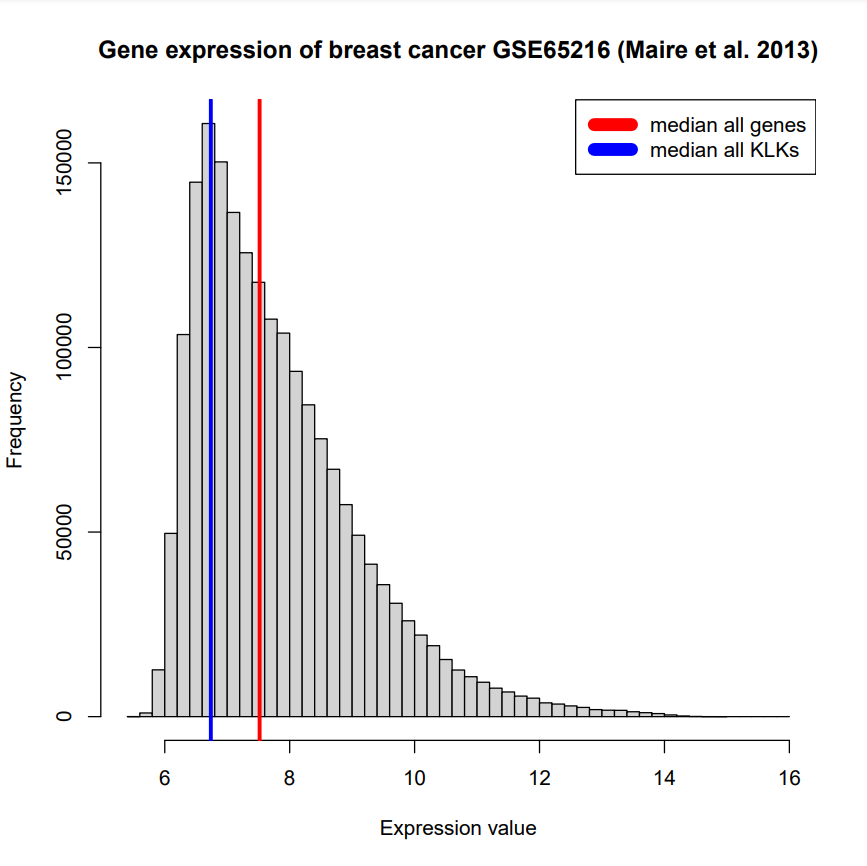

Histogram of breast cancer gene expression

#### Boxplots

[figure not shown]

Boxplot of KLK gene expression in breast cancer

Here, the pattern for the fairly low gene expression of KLKs is also recognizable. Most of the boxpots of the single KLK gene isoforms are lower than the median expression of the whole breast cancer genome. Some KLK isoforms like KLK2.3 are even below a gene expression value of 6, so KLK isoforms like these are clearly down-regulated. This is compatible with the finding of Yousef et al. in which they state an overall down-regulation of KLK gene expression in breast cancer. There are only two isoforms that exceed the median of the whole genome expression of the breast cancer set. These are the isoforms KLK4.4 and KLK8.8.  
KLK4 gene expression was found by Schmitt et al. to be up-regulated in breast cancer tissue as in comparison to healthy breast tissue. This seems to correspond with the finding shown in the boxplot, but only for the KLK4.4 isoform. So KLK4.4 needs to be investigated more carefully. In contrast to that, KLK8 seems to be higher expressed in both normal and cancer tissue.(Schmitt et al. 2013)

#### Heatmap

The dendrogram is the core for the emerging clustering in heatmaps. Here, clustering is performed after the complete-linkage method.

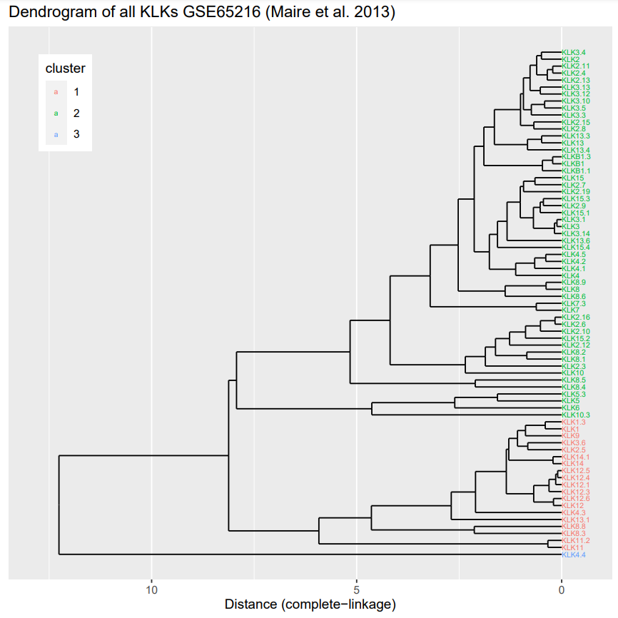

Dendrogram of KLK genes in breast cancer

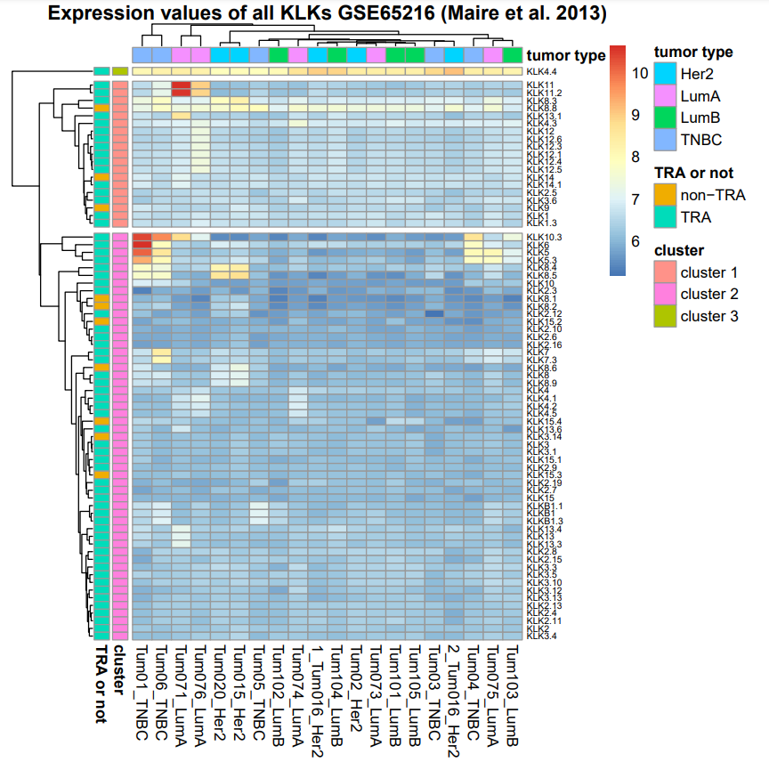

Heatmap of KLK gene expression in breast cancer

### PCA

The principal component analysis was conducted over the samples. Centering was enabled, while scaling was not included, due to the data being vsnrma normalized.

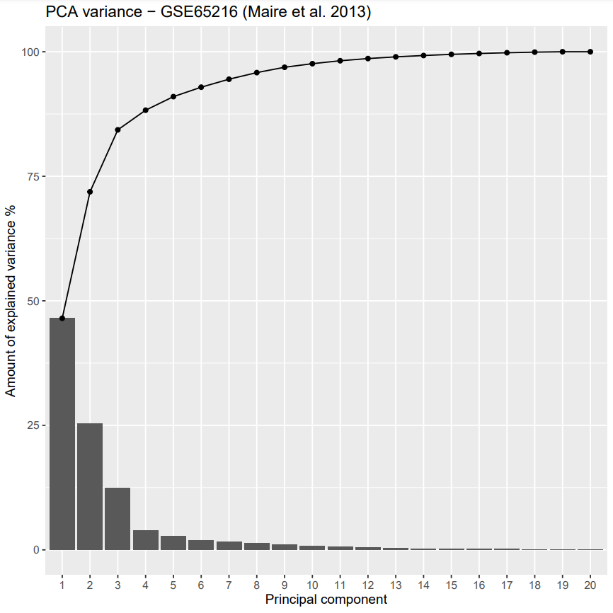

Variance plot of the principal components for breast cancer

The cumulative variance shows, that 72% of the total variance or of the total information is explained by the first 2 principal components (PCs). These two PCs are sufficient for the analysis of the distribution of the breast cancer samples across the loadings of the KLK gene expression.

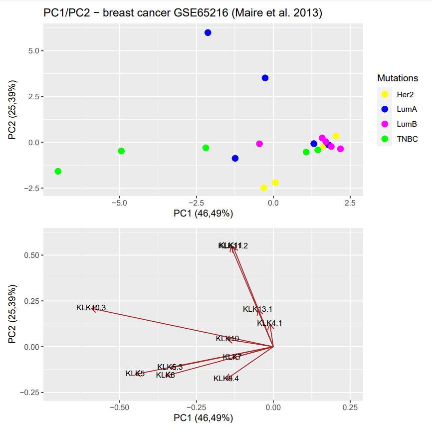

PC1 vs. PC2 with their respective loadings for breast cancer

## 4.3 Lung cancer GSE149507 (Cai et al. 2021)

The lung cancer microarray GSE149507 (Cai et al. 2021) were taken out of 6 patients with small cell lung cancer. The healthy lung tissue is adjacent to the carcinoma and the data set thereby consists of a total of 12 samples.

### Visualization of gene expression

#### Overview gene expression

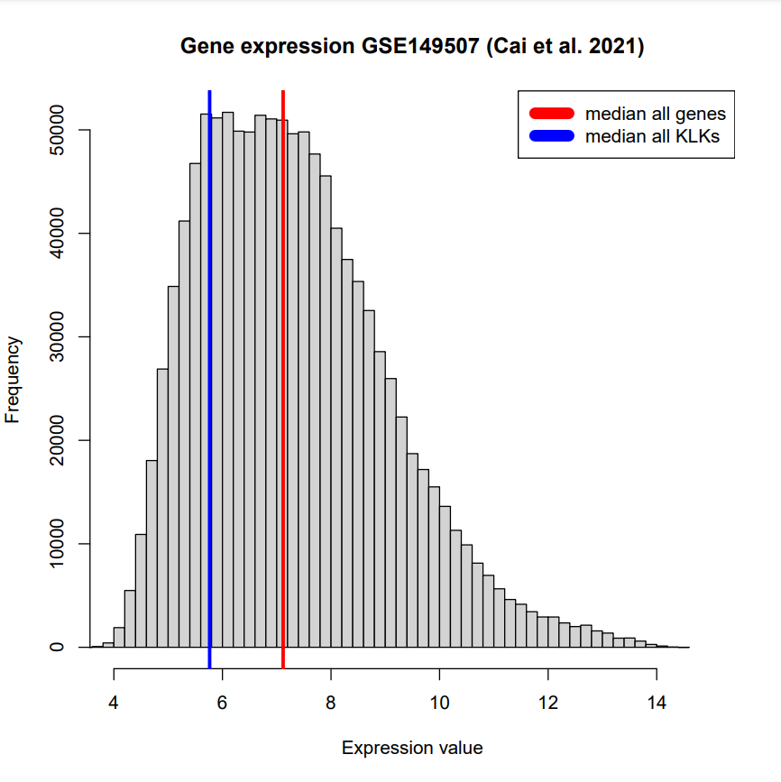

Histogram of lung cancer gene expression

#### Boxplots

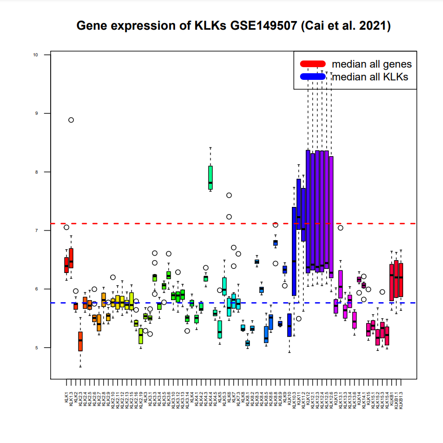

Boxplot of KLK gene expression in lung cancer

#### Heatmap

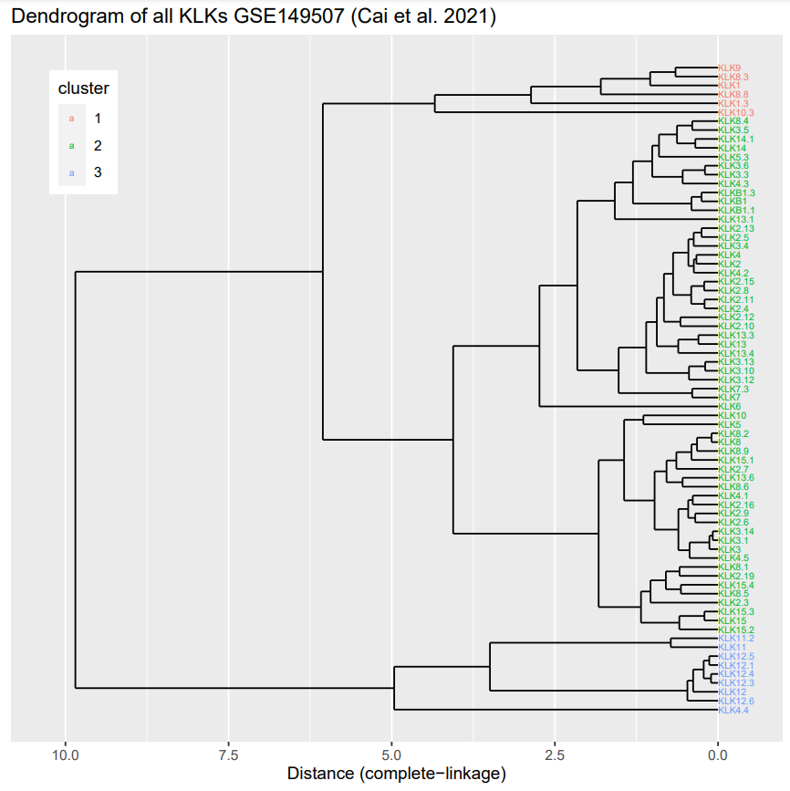

Dendrogram of KLK genes in lung cancer

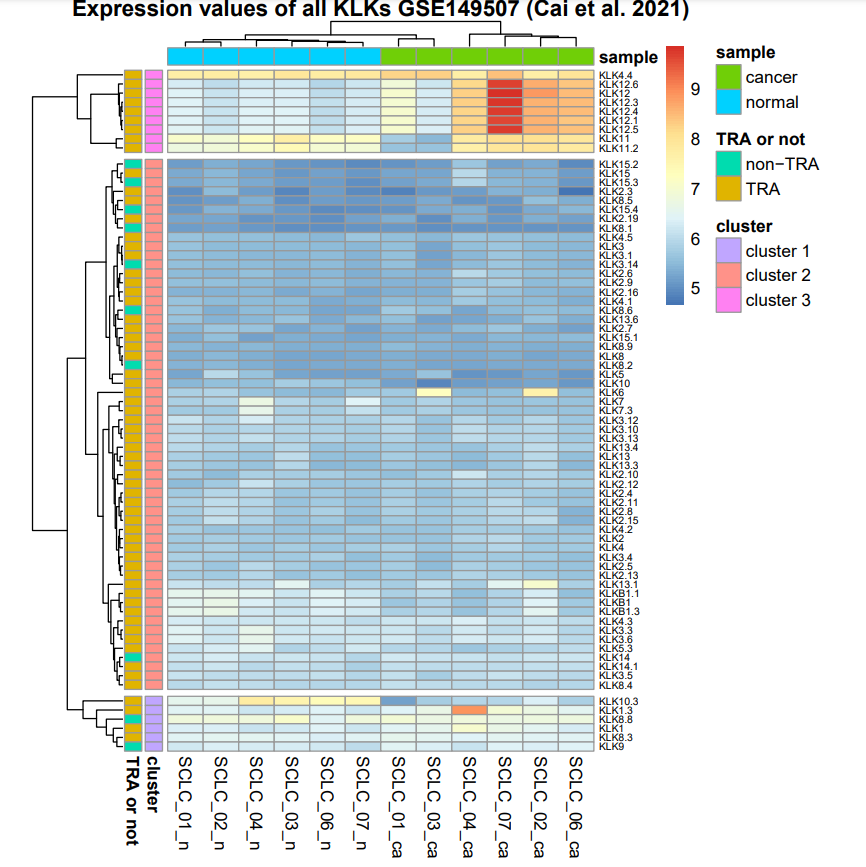

Heatmap of KLK gene expression in lung cancer

### PCA

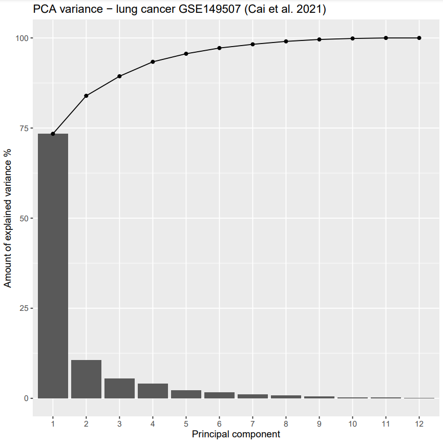

Variance plot of the principal components for lung cancer

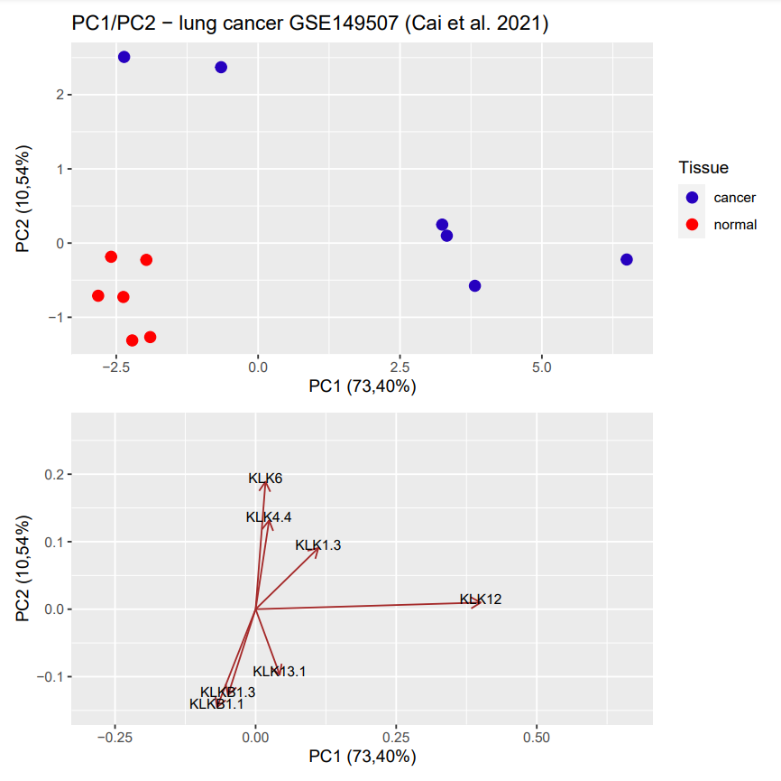

PC1 vs. PC2 with their respective loadings for lung cancer

# References

- Maire V, Némati F, Richardson M, Vincent-Salomon A et al. Polo-like kinase 1: a potential therapeutic option in combination with conventional chemotherapy for the management of patients with triple-negative breast cancer. Cancer Res 2013 Jan 15
- Cai L, Liu H, Huang F, Fujimoto J et al. Cell-autonomous immune gene expression is repressed in pulmonary neuroendocrine cells and small cell lung cancer. Commun Biol 2021 Mar 9
- Dinkelacker 2019. Chromosomal clustering of tissue restricted antigens, Dissertation, University Heidelberg, Germany.
- Dinkelacker 2007. A database of genes that are expressed in a tissue-restricted manner to analyse promiscous gene expression in medullary thymic epithelial cells. Diplomarbeit, Albert-Ludwigs-Universitaet, Freiburg, Germany.